# R Class one revision

Josue Iraduknda

2026-10-25

# Introduction

This document contains class practices and my trials referring to the Lecturer materials

# 1. Introduction to R

R is a programming language used for statistical computing, data analysis, and visualization.

## 1.1 Basic calculations

```r
2 + 5
```

```
## [1] 7
```

```r
10 - 3
```

```
## [1] 7
```

```r
5 * 4
```

```
## [1] 20
```

```r
20 / 5
```

```
## [1] 4
```

```r
2^2
```

```
## [1] 4
```

```r
sqrt(49)
```

```
## [1] 7
```

# 2. Data structures

## 2.1 Vectors

A vector stores elements of the same basic data type.

### Numeric vectors

```r
x <- c(0.6, 0.7)
age <- c(20, 35, 32, 29)

summary(age)
```

```
##    Min. 1st Qu.  Median    Mean 3rd Qu.    Max.
##   20.00   26.75   30.50   29.00   32.75   35.00
```

```r
mean(age)
```

```
## [1] 29
```

### Logical vectors

```r
x <- c(TRUE, FALSE)
x <- c(T, F)

x
```

```
## [1]  TRUE FALSE
```

### Character vectors

```r
x <- c("a", "b", "c")
class_gender <- c("M", "F", "F", "M")

x
```

```
## [1] "a" "b" "c"
```

```r
class_gender
```

```
## [1] "M" "F" "F" "M"
```

### Integer sequences

```r
x <- 9:29
x
```

```
##  [1]  9 10 11 12 13 14 15 16 17 18 19 20 21 22 23 24 25 26 27 28 29
```

### Complex numbers

```r
x <- c(1 + 0i, 2 + 4i)
x
```

```
## [1] 1+0i 2+4i
```

## 2.2 Matrices

A matrix stores elements of the same data type in rows and columns.

```r
x <- matrix(1:6, nrow = 2, ncol = 3)
x
```

```
##      [,1] [,2] [,3]
## [1,]    1    3    5
## [2,]    2    4    6
```

```r
y <- matrix(1:6, nrow = 3, ncol = 2)
y
```

```
##      [,1] [,2]
## [1,]    1    4
## [2,]    2    5
## [3,]    3    6
```

```r
x %*% y
```

```
##      [,1] [,2]
## [1,]   22   49
## [2,]   28   64
```

## 2.3 Lists

A list can contain elements of different data types.

```r
x <- list(1, "a", TRUE, 1 + 4i)
x
```

```
## [[1]]
## [1] 1
##
## [[2]]
## [1] "a"
##
## [[3]]
## [1] TRUE
##
## [[4]]
## [1] 1+4i
```

## 2.4 Factors

Factors represent categorical variables.

```r
x <- factor(c("yes", "yes", "no", "yes", "no"))
x
```

```
## [1] yes yes no  yes no
## Levels: no yes
```

```r
levels(x)
```

```
## [1] "no"  "yes"
```

## 2.5 Missing values

```r
x <- c(1, 2, NA, 10, 3)

is.na(x)
```

```
## [1] FALSE FALSE  TRUE FALSE FALSE
```

```r
x <- c(1, 2, 4, "NA", 5)
bad <- is.na(x)

print(bad)
```

```
## [1] FALSE FALSE FALSE FALSE FALSE
```

```r
x[!bad]
```

```
## [1] "1"  "2"  "4"  "NA" "5"
```

Notice that `"NA"` is a character string, whereas `NA` represents a missing value.

### Checking complete cases

```r
x <- c(1, 2, NA, 4, NA, 5)
y <- c("a", "b", NA, "d", NA, "f")

good <- complete.cases(x, y)
good
```

```
## [1]  TRUE  TRUE FALSE  TRUE FALSE  TRUE
```

## 2.6 Type coercion

R converts elements to a common type when necessary.

```r
sum(c(TRUE, TRUE, FALSE, FALSE, FALSE))
```

```
## [1] 2
```

# 3. Creating data frames

A data frame can contain different data types in separate columns.

```r
studentID <- c(1, 2, 3, 4, 5)
math_score <- c(12, 17, 10, 9, NA)
gender <- c("M", "F", "M", "M", "F")
it_score <- c(13, 18, 11, 10, 19)

scoredata <- data.frame(
  studentID,
  gender,
  math_score,
  it_score
)

scoredata
```

```
##   studentID gender math_score it_score
## 1         1      M         12       13
## 2         2      F         17       18
## 3         3      M         10       11
## 4         4      M          9       10
## 5         5      F         NA       19
```

```r
str(scoredata)
```

```
## 'data.frame':    5 obs. of  4 variables:
##  $ studentID : num  1 2 3 4 5
##  $ gender    : chr  "M" "F" "M" "M" ...
##  $ math_score: num  12 17 10 9 NA
##  $ it_score  : num  13 18 11 10 19
```

```r
summary(scoredata)
```

```
##    studentID       gender    math_score       it_score
##  Min.   :1   Length   :5   Min.   : 9.00   Min.   :10.0
##  1st Qu.:2   N.unique :2   1st Qu.: 9.75   1st Qu.:11.0
##  Median :3   N.blank  :0   Median :11.00   Median :13.0
##  Mean   :3   Min.nchar:1   Mean   :12.00   Mean   :14.2
##  3rd Qu.:4   Max.nchar:1   3rd Qu.:13.25   3rd Qu.:18.0
##  Max.   :5                 Max.   :17.00   Max.   :19.0
##                            NAs    :1
```

## 3.1 Entering data manually

```r
data_class2 <- data.frame(
  height = numeric(0),
  weight = numeric(0),
  bmi = numeric(0)
)

data_class2 <- edit(data_class2)
```

Run this code interactively in RStudio if you want to enter data through the data editor.

# 4. Data importation

R can import data from text files, spreadsheets, statistical software, and databases.

## 4.1 Importing a text file

The original document uses a local text file containing height and weight measurements.

The following code generates example data so that this report can run without that file.

```r
data_class <- data.frame(
  HEIGHT = c(
    161, 155, 158, 170, 160, 156, 162, 158, 158, 167,
    160, 155, 154, 155, 157, 157, 160, 158, 160, 160,
    152, 154, 150, 161, 162, 164, 161, 155, 159, 163,
    159, 160, 158, 165, 156, 163, 155, 164, 163, 168,
    157, 164, 154
  ),
  WEIGHT = c(
    50, 49, 42, 65, 60, 52, 58, 46, 45, 51,
    60, 42, 53, 48, 48, 48, 53, 52, 51, 53,
    44, 56, 63, 52, 57, 49, 52, 54, 46, 50,
    61, 55, 45, 63, 60, 56, 52, 47, 52, 55,
    48, 58, 55
  )
)

head(data_class)
```

```
##   HEIGHT WEIGHT
## 1    161     50
## 2    155     49
## 3    158     42
## 4    170     65
## 5    160     60
## 6    156     52
```

```r
tail(data_class)
```

```
##    HEIGHT WEIGHT
## 38    164     47
## 39    163     52
## 40    168     55
## 41    157     48
## 42    164     58
## 43    154     55
```

```r
data_class[10:20, ]
```

```
##    HEIGHT WEIGHT
## 10    167     51
## 11    160     60
## 12    155     42
## 13    154     53
## 14    155     48
## 15    157     48
## 16    157     48
## 17    160     53
## 18    158     52
## 19    160     51
## 20    160     53
```

To import the original file when you have it, use:

```r
data_class <- read.table(
  "class_data.txt",
  header = TRUE
)

names(data_class)
head(data_class)
tail(data_class)
```

## 4.2 Exploring built-in datasets

```r
data()
data("airquality")

names(airquality)
```

```
## [1] "Ozone"   "Solar.R" "Wind"    "Temp"    "Month"   "Day"
```

```r
str(airquality)
```

```
## 'data.frame':    153 obs. of  6 variables:
##  $ Ozone  : int  41 36 12 18 NA 28 23 19 8 NA ...
##  $ Solar.R: int  190 118 149 313 NA NA 299 99 19 194 ...
##  $ Wind   : num  7.4 8 12.6 11.5 14.3 14.9 8.6 13.8 20.1 8.6 ...
##  $ Temp   : int  67 72 74 62 56 66 65 59 61 69 ...
##  $ Month  : int  5 5 5 5 5 5 5 5 5 5 ...
##  $ Day    : int  1 2 3 4 5 6 7 8 9 10 ...
```

```r
head(airquality)
```

```
##   Ozone Solar.R Wind Temp Month Day
## 1    41     190  7.4   67     5   1
## 2    36     118  8.0   72     5   2
## 3    12     149 12.6   74     5   3
## 4    18     313 11.5   62     5   4
## 5    NA      NA 14.3   56     5   5
## 6    28      NA 14.9   66     5   6
```

```r
summary(airquality)
```

```
##      Ozone           Solar.R           Wind             Temp
##  Min.   :  1.00   Min.   :  7.0   Min.   : 1.700   Min.   :56.00
##  1st Qu.: 18.00   1st Qu.:115.8   1st Qu.: 7.400   1st Qu.:72.00
##  Median : 31.50   Median :205.0   Median : 9.700   Median :79.00
##  Mean   : 42.13   Mean   :185.9   Mean   : 9.958   Mean   :77.88
##  3rd Qu.: 63.25   3rd Qu.:258.8   3rd Qu.:11.500   3rd Qu.:85.00
##  Max.   :168.00   Max.   :334.0   Max.   :20.700   Max.   :97.00
##  NAs    :37       NAs    :7
##      Month            Day
##  Min.   :5.000   Min.   : 1.0
##  1st Qu.:6.000   1st Qu.: 8.0
##  Median :7.000   Median :16.0
##  Mean   :6.993   Mean   :15.8
##  3rd Qu.:8.000   3rd Qu.:23.0
##  Max.   :9.000   Max.   :31.0
##
```

# 5. Exploratory data analysis

## 5.1 Summary statistics

```r
data_class
```

```
##    HEIGHT WEIGHT
## 1     161     50
## 2     155     49
## 3     158     42
## 4     170     65
## 5     160     60
## 6     156     52
## 7     162     58
## 8     158     46
## 9     158     45
## 10    167     51
## 11    160     60
## 12    155     42
## 13    154     53
## 14    155     48
```

[output cut: 29 more lines]

```r
summary(data_class)
```

```
##      HEIGHT          WEIGHT
##  Min.   :150.0   Min.   :42.00
##  1st Qu.:156.0   1st Qu.:48.00
##  Median :159.0   Median :52.00
##  Mean   :159.3   Mean   :52.47
##  3rd Qu.:162.0   3rd Qu.:56.00
##  Max.   :170.0   Max.   :65.00
```

```r
str(data_class)
```

```
## 'data.frame':    43 obs. of  2 variables:
##  $ HEIGHT: num  161 155 158 170 160 156 162 158 158 167 ...
##  $ WEIGHT: num  50 49 42 65 60 52 58 46 45 51 ...
```

## 5.2 Means and standard deviations

```r
apply(data_class, 1, mean)
```

```
##  [1] 105.5 102.0 100.0 117.5 110.0 104.0 110.0 102.0 101.5 109.0 110.0  98.5
## [13] 103.5 101.5 102.5 102.5 106.5 105.0 105.5 106.5  98.0 105.0 106.5 106.5
## [25] 109.5 106.5 106.5 104.5 102.5 106.5 110.0 107.5 101.5 114.0 108.0 109.5
## [37] 103.5 105.5 107.5 111.5 102.5 111.0 104.5
```

```r
apply(data_class, 2, sd)
```

```
##   HEIGHT   WEIGHT
## 4.304444 5.750150
```

```r
c(
  Mean = mean(data_class$HEIGHT),
  SD = sd(data_class$HEIGHT)
)
```

```
##       Mean         SD
## 159.255814   4.304444
```

```r
c(
  Mean = mean(data_class$WEIGHT),
  SD = sd(data_class$WEIGHT)
)
```

```
##     Mean       SD
## 52.46512  5.75015
```

# 6. Relationships between variables

## 6.1 Categorical and continuous variables

The `iris` dataset is built into R.

```r
data("iris")
head(iris)
```

```
##   Sepal.Length Sepal.Width Petal.Length Petal.Width Species
## 1          5.1         3.5          1.4         0.2  setosa
## 2          4.9         3.0          1.4         0.2  setosa
## 3          4.7         3.2          1.3         0.2  setosa
## 4          4.6         3.1          1.5         0.2  setosa
## 5          5.0         3.6          1.4         0.2  setosa
## 6          5.4         3.9          1.7         0.4  setosa
```

```r
mean(iris$Petal.Length)
```

```
## [1] 3.758
```

```r
mean(iris$Petal.Length[iris$Species == "setosa"])
```

```
## [1] 1.462
```

```r
mean(iris$Petal.Length[iris$Species == "versicolor"])
```

```
## [1] 4.26
```

```r
mean(iris$Petal.Length[iris$Species == "virginica"])
```

```
## [1] 5.552
```

### Grouped statistics

```r
by(iris$Petal.Length, iris$Species, mean)
```

```
## iris$Species: setosa
## [1] 1.462
## ------------------------------------------------------------
## iris$Species: versicolor
## [1] 4.26
## ------------------------------------------------------------
## iris$Species: virginica
## [1] 5.552
```

```r
by(iris$Petal.Length, iris$Species, sd)
```

```
## iris$Species: setosa
## [1] 0.173664
## ------------------------------------------------------------
## iris$Species: versicolor
## [1] 0.469911
## ------------------------------------------------------------
## iris$Species: virginica
## [1] 0.5518947
```

```r
by(iris$Petal.Length, iris$Species, summary)
```

```
## iris$Species: setosa
##    Min. 1st Qu.  Median    Mean 3rd Qu.    Max.
##   1.000   1.400   1.500   1.462   1.575   1.900
## ------------------------------------------------------------
## iris$Species: versicolor
##    Min. 1st Qu.  Median    Mean 3rd Qu.    Max.
##    3.00    4.00    4.35    4.26    4.60    5.10
## ------------------------------------------------------------
## iris$Species: virginica
##    Min. 1st Qu.  Median    Mean 3rd Qu.    Max.
##   4.500   5.100   5.550   5.552   5.875   6.900
```

### Box-and-whisker plot

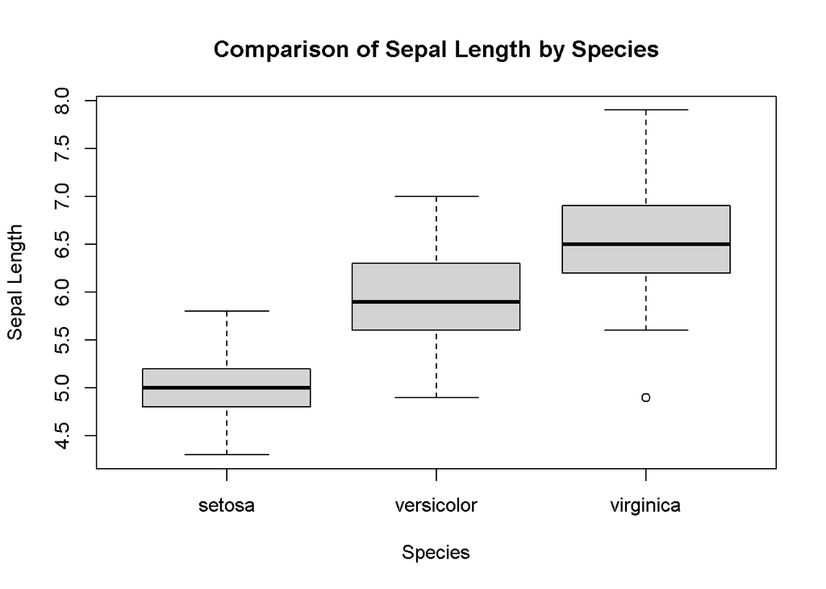

```r
boxplot(
  Sepal.Length ~ Species,
  data = iris,
  main = "Comparison of Sepal Length by Species",
  xlab = "Species",
  ylab = "Sepal Length"
)
```

## 6.2 Relationships between categorical variables

```r
ucba <- data.frame(UCBAdmissions)

head(ucba)
```

```
##      Admit Gender Dept Freq
## 1 Admitted   Male    A  512
## 2 Rejected   Male    A  313
## 3 Admitted Female    A   89
## 4 Rejected Female    A   19
## 5 Admitted   Male    B  353
## 6 Rejected   Male    B  207
```

```r
cross <- xtabs(Freq ~ Gender + Admit, data = ucba)
cross
```

```
##         Admit
## Gender   Admitted Rejected
##   Male       1198     1493
##   Female      557     1278
```

```r
prop.table(cross, 1)
```

```
##         Admit
## Gender    Admitted  Rejected
##   Male   0.4451877 0.5548123
##   Female 0.3035422 0.6964578
```

## 6.3 Simpson’s paradox

Simpson’s paradox occurs when a relationship observed in combined data disappears or reverses when the data are divided into groups.

```r
cross2 <- xtabs(
  Freq ~ Gender + Admit,
  data = ucba[ucba$Dept == "F", ]
)

prop.table(cross2, 1)
```

```
##         Admit
## Gender     Admitted   Rejected
##   Male   0.05898123 0.94101877
##   Female 0.07038123 0.92961877
```

# 7. Data visualization

## 7.1 Bar charts

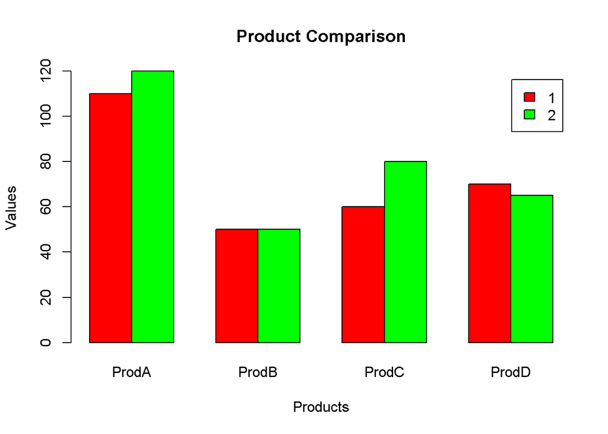

```r
dat <- read.table(
  text = "ProdA ProdB ProdC ProdD
1 110 50 60 70
2 120 50 80 65",
  header = TRUE
)

barplot(
  as.matrix(dat),
  beside = TRUE,
  col = c("red", "green"),
  main = "Product Comparison",
  xlab = "Products",
  ylab = "Values",
  legend.text = TRUE
)
```

## 7.2 Another bar chart

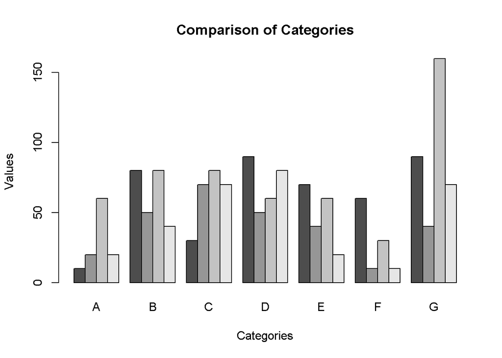

```r
dat <- read.table(
  text = "A B C D E F G
1 10 80 30 90 70 60 90
2 20 50 70 50 40 10 40
3 60 80 80 60 60 30 160
4 20 40 70 80 20 10 70",
  header = TRUE
)

barplot(
  as.matrix(dat),
  main = "Comparison of Categories",
  xlab = "Categories",
  ylab = "Values",
  beside = TRUE
)
```

## 7.3 Scatter plots

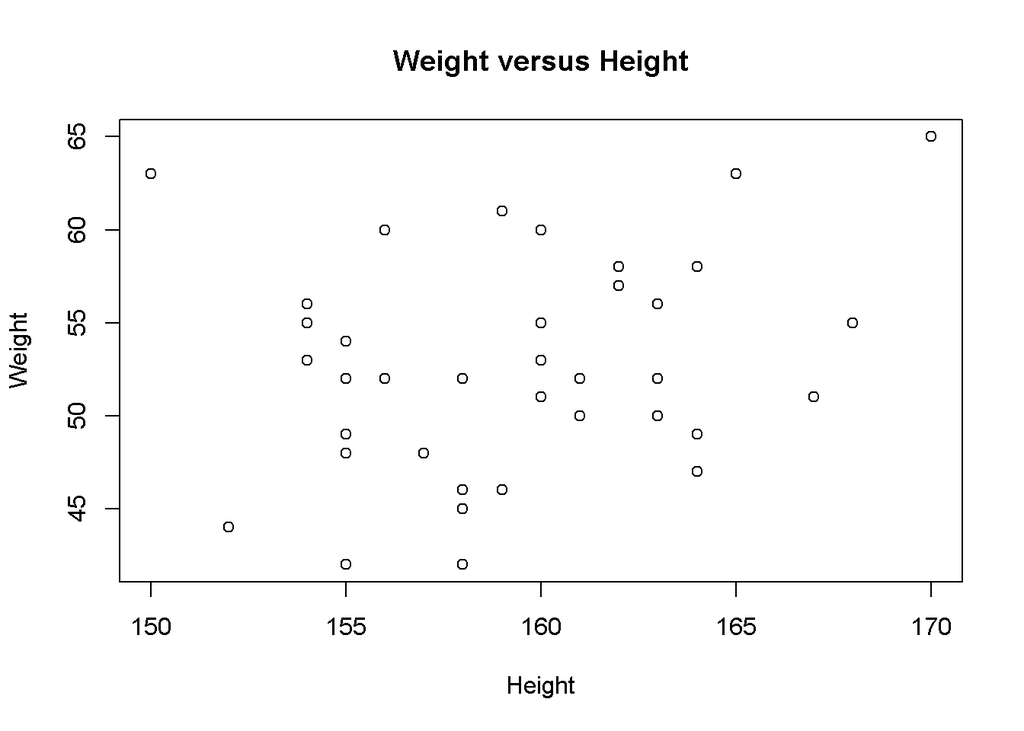

```r
plot(
  WEIGHT ~ HEIGHT,
  data = data_class,
  main = "Weight versus Height",
  xlab = "Height",
  ylab = "Weight"
)
```

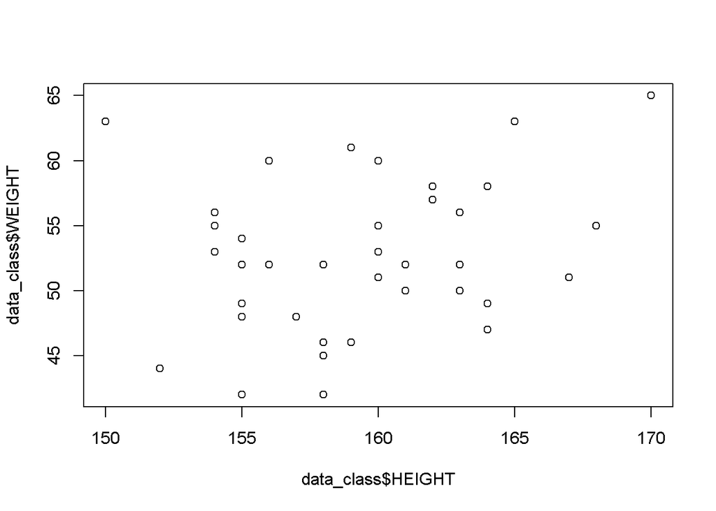

```r
plot(data_class$HEIGHT, data_class$WEIGHT)
```

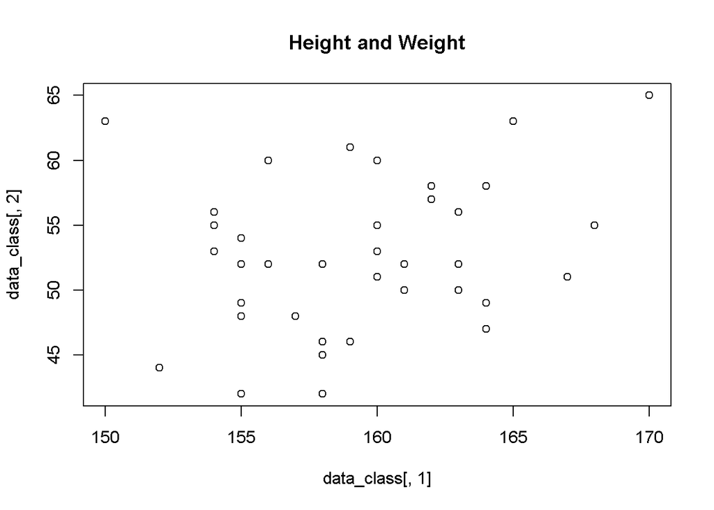

```r
plot(
  data_class[, 1],
  data_class[, 2],
  main = "Height and Weight"
)
```

```r
cor(data_class$HEIGHT, data_class$WEIGHT)
```

```
## [1] 0.2663495
```

## 7.4 Histograms

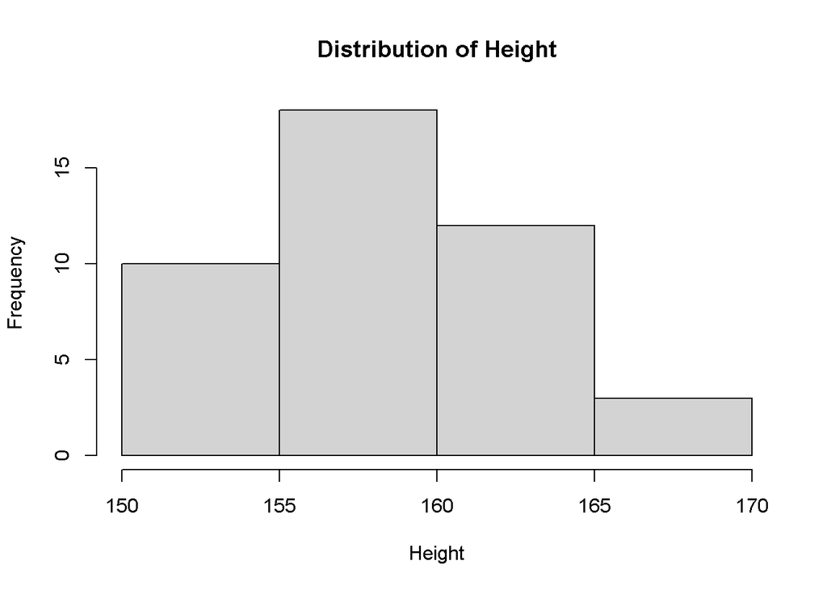

```r
hist(
  data_class$HEIGHT,
  main = "Distribution of Height",
  xlab = "Height"
)
```

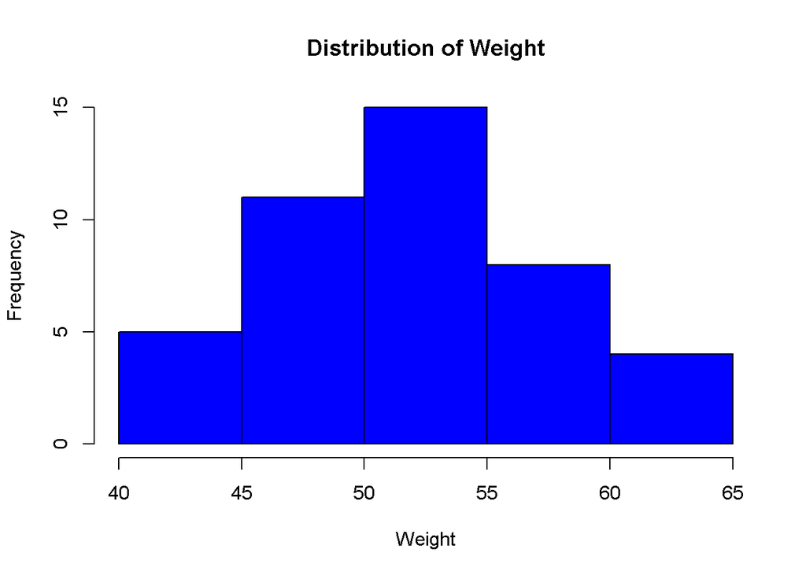

```r
hist(
  data_class$WEIGHT,
  main = "Distribution of Weight",
  xlab = "Weight",
  col = "blue"
)
```

# 8. Linear models

## 8.1 Fitting a linear regression model

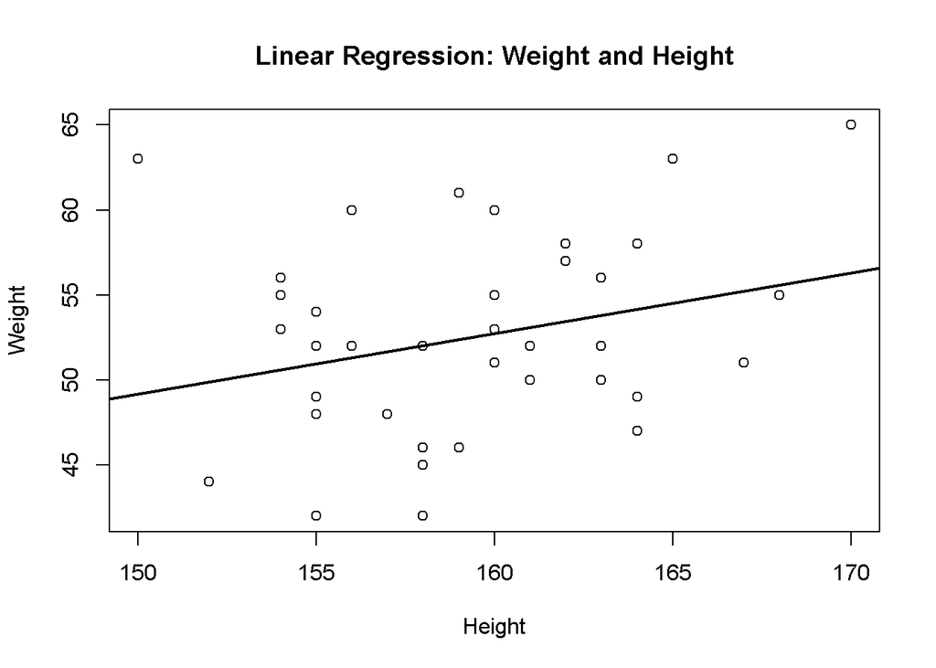

```r
plot(
  WEIGHT ~ HEIGHT,
  data = data_class,
  main = "Linear Regression: Weight and Height",
  xlab = "Height",
  ylab = "Weight"
)

model1 <- lm(WEIGHT ~ HEIGHT, data = data_class)

abline(model1, lwd = 2)
```

```r
summary(model1)
```

```
##
## Call:
## lm(formula = WEIGHT ~ HEIGHT, data = data_class)
##
## Residuals:
##      Min       1Q   Median       3Q      Max
## -10.0183  -3.7299  -0.5764   3.7027  13.8282
##
## Coefficients:
##             Estimate Std. Error t value Pr(>|t|)
## (Intercept)  -4.1992    32.0363  -0.131   0.8964
## HEIGHT        0.3558     0.2011   1.769   0.0843 .
## ---
## Signif. codes:  0 '***' 0.001 '**' 0.01 '*' 0.05 '.' 0.1 ' ' 1
##
## Residual standard error: 5.61 on 41 degrees of freedom
## Multiple R-squared:  0.07094,    Adjusted R-squared:  0.04828
## F-statistic: 3.131 on 1 and 41 DF,  p-value: 0.08427
```

## 8.2 Predicting height from weight

```r
data_lm <- lm(HEIGHT ~ WEIGHT, data = data_class)

summary(data_lm)
```

```
##
## Call:
## lm(formula = HEIGHT ~ WEIGHT, data = data_class)
##
## Residuals:
##      Min       1Q   Median       3Q      Max
## -11.3563  -2.6662   0.2326   2.0378   8.2449
##
## Coefficients:
##             Estimate Std. Error t value Pr(>|t|)
## (Intercept) 148.7951     5.9466  25.022   <2e-16 ***
## WEIGHT        0.1994     0.1127   1.769   0.0843 .
## ---
## Signif. codes:  0 '***' 0.001 '**' 0.01 '*' 0.05 '.' 0.1 ' ' 1
##
## Residual standard error: 4.199 on 41 degrees of freedom
## Multiple R-squared:  0.07094,    Adjusted R-squared:  0.04828
## F-statistic: 3.131 on 1 and 41 DF,  p-value: 0.08427
```

## 8.3 Regression diagnostic plots

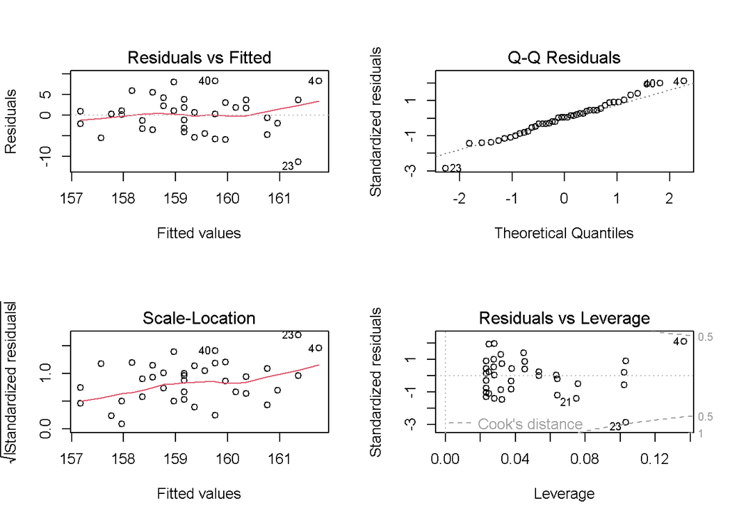

```r
par(mfrow = c(2, 2))
plot(data_lm)
```

```r
par(mfrow = c(1, 1))
```

## 8.4 Linear regression and a smooth curve

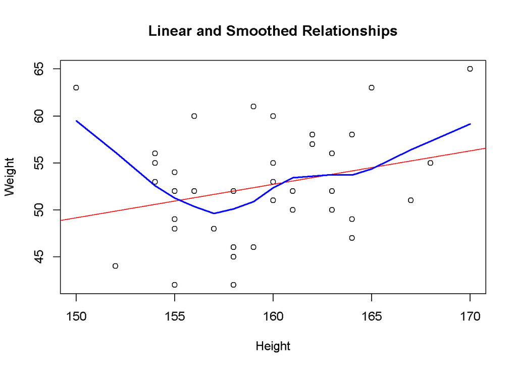

```r
plot(
  WEIGHT ~ HEIGHT,
  data = data_class,
  main = "Linear and Smoothed Relationships",
  xlab = "Height",
  ylab = "Weight"
)

abline(
  lm(WEIGHT ~ HEIGHT, data = data_class),
  col = "red"
)

lines(
  lowess(data_class$HEIGHT, data_class$WEIGHT),
  col = "blue",
  lwd = 2
)
```

```r
cor(data_class$HEIGHT, data_class$WEIGHT)
```

```
## [1] 0.2663495
```

```r
lm(WEIGHT ~ HEIGHT, data = data_class)
```

```
##
## Call:
## lm(formula = WEIGHT ~ HEIGHT, data = data_class)
##
## Coefficients:
## (Intercept)       HEIGHT
##     -4.1992       0.3558
```

# 9. Data management

## 9.1 Creating a new variable: BMI

Body Mass Index (BMI) is calculated by dividing weight in kilograms by height in metres squared.

$$BMI = \frac{Weight\ (kg)}{Height\ (m)^2}$$

```r
BMI <- data_class$WEIGHT /
  (data_class$HEIGHT / 100)^2

BMI
```

```
##  [1] 19.28938 20.39542 16.82423 22.49135 23.43750 21.36752 22.10029 18.42653
##  [9] 18.02596 18.28678 23.43750 17.48179 22.34778 19.97919 19.47341 19.47341
## [17] 20.70312 20.83000 19.92187 20.70312 19.04432 23.61275 28.00000 20.06095
## [25] 21.71925 18.21832 20.06095 22.47659 18.19548 18.81892 24.12879 21.48437
## [33] 18.02596 23.14050 24.65483 21.07720 21.64412 17.47472 19.57168 19.48696
## [41] 19.47341 21.56454 23.19109
```

```r
BMI <- round(
  data_class$WEIGHT /
    (data_class$HEIGHT / 100)^2,
  digits = 2
)

BMI
```

```
##  [1] 19.29 20.40 16.82 22.49 23.44 21.37 22.10 18.43 18.03 18.29 23.44 17.48
## [13] 22.35 19.98 19.47 19.47 20.70 20.83 19.92 20.70 19.04 23.61 28.00 20.06
## [25] 21.72 18.22 20.06 22.48 18.20 18.82 24.13 21.48 18.03 23.14 24.65 21.08
## [37] 21.64 17.47 19.57 19.49 19.47 21.56 23.19
```

### Adding BMI to the data frame

```r
head(cbind(data_class, BMI), n = 5)
```

```
##   HEIGHT WEIGHT   BMI
## 1    161     50 19.29
## 2    155     49 20.40
## 3    158     42 16.82
## 4    170     65 22.49
## 5    160     60 23.44
```

```r
new_data_class <- cbind(data_class, BMI)

tail(new_data_class, n = 10)
```

```
##    HEIGHT WEIGHT   BMI
## 34    165     63 23.14
## 35    156     60 24.65
## 36    163     56 21.08
## 37    155     52 21.64
## 38    164     47 17.47
## 39    163     52 19.57
## 40    168     55 19.49
## 41    157     48 19.47
## 42    164     58 21.56
## 43    154     55 23.19
```

## 9.2 Summary of BMI

```r
summary(BMI)
```

```
##    Min. 1st Qu.  Median    Mean 3rd Qu.    Max.
##   16.82   19.16   20.40   20.70   22.23   28.00
```

```r
stem(BMI, scale = 2)
```

```
##
##   The decimal point is at the |
##
##   16 | 8
##   17 | 55
##   18 | 0022348
##   19 | 03555569
##   20 | 0114778
##   21 | 145667
##   22 | 1455
##   23 | 12446
##   24 | 17
##   25 |
##   26 |
##   27 |
##   28 | 0
```

# 10. Working with dates

## 10.1 Today’s date

```r
today <- Sys.Date()

format(today, format = "%B %d %Y")
```

```
## [1] "October 31 2026"
```

```r
format(today, format = "%A")
```

```
## [1] "Saturday"
```

## 10.2 Calculating age in days

```r
today <- Sys.Date()
dob <- as.Date("1982-02-10")

difftime(today, dob, units = "days")
```

```
## Time difference of 16334 days
```

## 10.3 Difference between two dates

```r
startdate <- as.Date("2004-02-13")
enddate <- as.Date("2011-01-22")

days <- enddate - startdate
days
```

```
## Time difference of 2535 days
```

# 11. Subsetting and data cleaning

## 11.1 Creating a leadership dataset

```r
manager <- c(1, 2, 3, 4, 5)
country <- c("US", "US", "UK", "UK", "UK")
gender <- c("M", "F", "F", "M", "F")
age <- c(32, 45, 25, 39, 99)

q1 <- c(5, 3, 3, 3, 2)
q2 <- c(4, 5, 5, 3, 2)
q3 <- c(5, 2, 5, 4, 1)
q4 <- c(5, 5, 5, NA, 2)
q5 <- c(5, 5, 2, NA, 1)

leadership <- data.frame(
  manager,
  country,
  gender,
  age,
  q1, q2, q3, q4, q5
)

str(leadership)
```

```
## 'data.frame':    5 obs. of  9 variables:
##  $ manager: num  1 2 3 4 5
##  $ country: chr  "US" "US" "UK" "UK" ...
##  $ gender : chr  "M" "F" "F" "M" ...
##  $ age    : num  32 45 25 39 99
##  $ q1     : num  5 3 3 3 2
##  $ q2     : num  4 5 5 3 2
##  $ q3     : num  5 2 5 4 1
##  $ q4     : num  5 5 5 NA 2
##  $ q5     : num  5 5 2 NA 1
```

```r
names(leadership)
```

```
## [1] "manager" "country" "gender"  "age"     "q1"      "q2"      "q3"
## [8] "q4"      "q5"
```

## 11.2 Handling missing values

In this example, the value 99 is treated as a missing age.

```r
leadership$age[leadership$age == 99] <- NA
```

### Creating age categories

```r
leadership$agecat <- NA_character_

leadership$agecat[
  leadership$age > 75
] <- "Elder"

leadership$agecat[
  leadership$age >= 35 & leadership$age <= 75
] <- "Middle Aged"

leadership$agecat[
  leadership$age < 35
] <- "Young"

leadership
```

```
##   manager country gender age q1 q2 q3 q4 q5      agecat
## 1       1      US      M  32  5  4  5  5  5       Young
## 2       2      US      F  45  3  5  2  5  5 Middle Aged
## 3       3      UK      F  25  3  5  5  5  2       Young
## 4       4      UK      M  39  3  3  4 NA NA Middle Aged
## 5       5      UK      F  NA  2  2  1  2  1        <NA>
```

### Identifying missing values

```r
is.na(leadership[, 5:9])
```

```
##         q1    q2    q3    q4    q5
## [1,] FALSE FALSE FALSE FALSE FALSE
## [2,] FALSE FALSE FALSE FALSE FALSE
## [3,] FALSE FALSE FALSE FALSE FALSE
## [4,] FALSE FALSE FALSE  TRUE  TRUE
## [5,] FALSE FALSE FALSE FALSE FALSE
```

### Removing rows with missing values

```r
newdata <- na.omit(leadership)
newdata
```

```
##   manager country gender age q1 q2 q3 q4 q5      agecat
## 1       1      US      M  32  5  4  5  5  5       Young
## 2       2      US      F  45  3  5  2  5  5 Middle Aged
## 3       3      UK      F  25  3  5  5  5  2       Young
```

`na.omit()` removes rows containing missing values in any column.

# 12. Sorting data

```r
order(leadership$age)
```

```
## [1] 3 1 4 2 5
```

```r
newdata2 <- leadership[
  order(leadership$age),
]

newdata2
```

```
##   manager country gender age q1 q2 q3 q4 q5      agecat
## 3       3      UK      F  25  3  5  5  5  2       Young
## 1       1      US      M  32  5  4  5  5  5       Young
## 4       4      UK      M  39  3  3  4 NA NA Middle Aged
## 2       2      US      F  45  3  5  2  5  5 Middle Aged
## 5       5      UK      F  NA  2  2  1  2  1        <NA>
```

# 13. Merging data frames

The `merge()` function joins data frames horizontally using common key columns.

For example:

```r
merge(dataframeA, dataframeB, by = "ID")

merge(
  dataframeA,
  dataframeB,
  by = c("ID", "country")
)
```

The `rbind()` function combines data frames vertically when their columns are compatible.

```r
data1 <- data.frame(
  ID = c(1, 2),
  score = c(12, 15)
)

data2 <- data.frame(
  ID = c(3, 4),
  score = c(18, 20)
)

rbind(data1, data2)
```

```
##   ID score
## 1  1    12
## 2  2    15
## 3  3    18
## 4  4    20
```

# 14. Selecting variables and observations

## 14.1 Selecting columns

```r
newdata3 <- leadership[, 5:9]
newdata3
```

```
##   q1 q2 q3 q4 q5
## 1  5  4  5  5  5
## 2  3  5  2  5  5
## 3  3  5  5  5  2
## 4  3  3  4 NA NA
## 5  2  2  1  2  1
```

```r
myvars <- c("q1", "q2", "q3", "q4", "q5")

newdata3 <- leadership[myvars]
newdata3
```

```
##   q1 q2 q3 q4 q5
## 1  5  4  5  5  5
## 2  3  5  2  5  5
## 3  3  5  5  5  2
## 4  3  3  4 NA NA
## 5  2  2  1  2  1
```

## 14.2 Removing columns

```r
newdata4 <- leadership[, c(-1, -2)]
newdata4
```

```
##   gender age q1 q2 q3 q4 q5      agecat
## 1      M  32  5  4  5  5  5       Young
## 2      F  45  3  5  2  5  5 Middle Aged
## 3      F  25  3  5  5  5  2       Young
## 4      M  39  3  3  4 NA NA Middle Aged
## 5      F  NA  2  2  1  2  1        <NA>
```

```r
newdata5 <- leadership[, c(-1, -7)]
newdata5
```

```
##   country gender age q1 q2 q4 q5      agecat
## 1      US      M  32  5  4  5  5       Young
## 2      US      F  45  3  5  5  5 Middle Aged
## 3      UK      F  25  3  5  5  2       Young
## 4      UK      M  39  3  3 NA NA Middle Aged
## 5      UK      F  NA  2  2  2  1        <NA>
```

## 14.3 Accessing a column

```r
leadership[[4]]
```

```
## [1] 32 45 25 39 NA
```

```r
leadership$age
```

```
## [1] 32 45 25 39 NA
```

Both expressions access the age column.

## 14.4 Selecting rows

```r
newdata6 <- leadership[c(2, 4, 5), ]

newdata6
```

```
##   manager country gender age q1 q2 q3 q4 q5      agecat
## 2       2      US      F  45  3  5  2  5  5 Middle Aged
## 4       4      UK      M  39  3  3  4 NA NA Middle Aged
## 5       5      UK      F  NA  2  2  1  2  1        <NA>
```

## 14.5 Selecting rows using conditions

```r
newdata7 <- subset(
  leadership,
  age >= 35 | age < 24,
  select = c(q1, q2, q3, q4, q5)
)

newdata7
```

```
##   q1 q2 q3 q4 q5
## 2  3  5  2  5  5
## 4  3  3  4 NA NA
```

### Selecting male managers older than 30

```r
newdata8 <- subset(
  leadership,
  gender == "M" & age > 30
)

newdata8
```

```
##   manager country gender age q1 q2 q3 q4 q5      agecat
## 1       1      US      M  32  5  4  5  5  5       Young
## 4       4      UK      M  39  3  3  4 NA NA Middle Aged
```

### Data management with dplyr

```r
library(dplyr)
library(nycflights13)
library(tidyverse)

View(flights)

result <- flights %>%
  group_by(carrier) %>%
  summarise(total_flights = n())

print(result)
```

```
## # A tibble: 16 × 2
##    carrier total_flights
##    <chr>           <int>
##  1 9E              18460
##  2 AA              32729
##  3 AS                714
##  4 B6              54635
##  5 DL              48110
##  6 EV              54173
##  7 F9                685
##  8 FL               3260
##  9 HA                342
## 10 MQ              26397
## 11 OO                 32
## 12 UA              58665
## 13 US              20536
## 14 VX               5162
## 15 WN              12275
## 16 YV                601
```

### data visualization

```r
library(ggplot2)

data("mtcars")

view(mtcars)
table(mtcars$cyl)
```

```
##
##  4  6  8
## 11  7 14
```

```r
#barplot(table(mtcars$cyl),main =)

#ggplot(data = mtcars,ass(x=wt,y=))
```